# Relatório de Teoria - Script

# Metodo

Para estimação da distribuição foi utilizado o método:

**Paramétrico**

Esse método é utilizado para poucas observações. É atribuido a ele uma distribuição conhecida (distribuição teórica)

**Não Paramétrico**

Esse método é utilizado para um grande número de observações. Nesse caso aplicamos uma distribuição empírica.

**Organizando o banco de dados**

```r
setwd("D:/Google Drive/2 - Ufpb/P5/Teoria/Prova/")
```

```r
#transformando dados em uma lista de tamanho 12.

dados=list()
length(dados)=12
for(i in 1:12){
  dados[[i]]=read.csv(paste("grupo4am",i,".csv",sep=""))
}
#S é uma lista numerica com 12 informações
S=c()
N=c()
N=numeric(12)
S=numeric(12)
```

## Respostas da Letra A

**Separando as informações**

```
Começando pela análise do banco de dados, este é formado por 455 observações onde encontramos os valores da severidade da carteira (x) e da frequência dos sinistros.
```

**Severidade = X**

```r
#Criando um objeto apenas para a severidade

x <-c((dados[[1]][,2]),(0), (dados[[3]][,2]), (dados[[4]][,2]), (dados[[5]][,2]), (dados[[6]][,2]), (dados[[7]][,2]), (dados[[8]][,2]), (dados[[9]][,2]), (dados[[10]][,2]), (dados[[11]][,2]), (dados[[12]][,2]))
```

**Frequencia = n**

```r
#Criando um objeto apenas para a frequência

n <-c((dados[[1]][,1]), (dados[[2]][,1]), (dados[[3]][,1]), (dados[[4]][,1]), (dados[[5]][,1]), (dados[[6]][,1]), (dados[[7]][,1]), (dados[[8]][,1]), (dados[[9]][,1]), (dados[[10]][,1]), (dados[[11]][,1]), (dados[[12]][,1]))
```

**Histogramas**

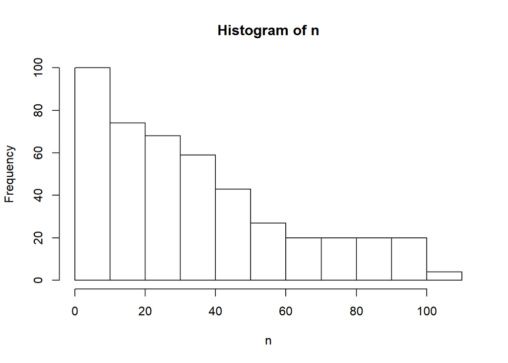

```r
#analisando o histograma é possivel ver que os dados não tem forma normal.
hist(n)
```

O histograma do número de sinistros(n) ocorridos em 1 ano mostra que os dados estão concentrados na parte esquerda do gráfico, ou seja, a carteira da seguradora hipotética é mais frequente acontecerem uma quantidade sinistros entre 0 e 40 por ano

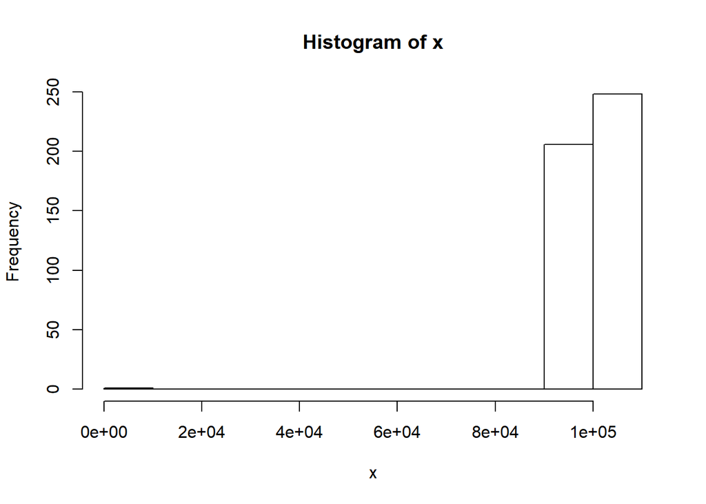

```r
hist(x)
```

**Severidade da Carteira**

```r
#Dados[[1]][,2] = Primeiro da lista, segunda coluna

S=sum((dados[[1]][,2]), (dados[[3]][,2]), (dados[[4]][,2]), (dados[[5]][,2]), (dados[[6]][,2]), (dados[[7]][,2]), (dados[[8]][,2]), (dados[[9]][,2]), (dados[[10]][,2]), (dados[[11]][,2]), (dados[[12]][,2]))
S
```

```
## [1] 45400100
```

```r
Ex <- mean(x)
Vx <- var(x)
Dpx <- sd(x)
CVx <- Dpx / Ex
```

```r
Ex   #Média dos valores de x
```

```
## [1] 99780.44
```

```r
Vx   #Variancia dos valores de x
```

```
## [1] 21978146
```

```r
Dpx   #Desvio padrão dos valores de x
```

```
## [1] 4688.086
```

```r
CVx   #Coeficiente de variação de x
```

```
## [1] 0.04698401
```

O valor médio pago é de $ 99780.44, esses valores estão dispersos $ 21978146, estão dispersos da média $ 4688.086 e a medida de variabilidade da média é de 4%.

**Frequência observada da carteira**

```r
En <- mean(n)
Vn <- var(n)
Dpn <- sd(n)
CVn <- Dpn / En
```

```r
En   #Média dos valores de n
```

```
## [1] 34.5978
```

```r
Vn   #Variancia dos valores de n
```

```
## [1] 740.9238
```

```r
Dpn   #Desvio padrão dos valores de n
```

```
## [1] 27.21992
```

```r
CVn   #Coeficiente de variação de s
```

```
## [1] 0.7867527
```

[output not shown]

**Sinistro Agregado**

```
E[Scol] = E[N]*E[X]

V[Scol] = V[X]*E[N] + E[X]2 *V[N]`
```

```r
Es <- (En*Ex)
Vs <- (En*Vx)+(Ex)^2*Vn
Ds <- sqrt(Vs)
CVs <- Ds/Es
```

```r
Es   #Média dos valores de S
```

```
## [1] 3452184
```

```r
Vs   #Variancia dos valores de S
```

```
## [1] 7.377499e+12
```

```r
Ds   #Desvio padrão dos valores de S
```

```
## [1] 2716155
```

```r
CVs   #Desvio padrão dos valores de S
```

```
## [1] 0.7867933
```

[output not shown]

**Prêmio Puro com 1% de nivel de significância**

Pp=E[s]+Z(1-a)*DesvioS

```r
#qnorm retorna o Z(1-a)

PP1 = Es+qnorm(1-0.01)*Ds
PP5 = Es+qnorm(1-0.05)*Ds
PP10 = Es+qnorm(1-0.10)*Ds
```

```r
PP1   #Prêmio puro com 1% de significância
```

```
## [1] 9770906
```

```r
PP5   #Prêmio puro com 5% de significância
```

```
## [1] 7919862
```

```r
PP10   #Prêmio puro com 10% de significância
```

```
## [1] 6933077
```

```
Calculo do Prêmio Puro quando S tem distribuição que se aproxima da Normal
```

**Prêmio Puro pela fórmula**

teta = (Z(1-a)*DesvioS)/Es

Pp = E[s]*(1+teta)

```r
#Carregamentos para 1%, 5%, 10% de significância

teta1=((qnorm(1-0.01)*Ds)/Es)
teta5=((qnorm(1-0.05)*Ds)/Es)
teta10=((qnorm(1-0.1)*Ds)/Es)
```

```r
teta1   #Carregamento com 1% de significância
```

```
## [1] 1.830355
```

```r
teta5   #Carregamento com 5% de significância
```

```
## [1] 1.29416
```

```r
teta10   #Carregamento com 10% de significância
```

```
## [1] 1.008316
```

```r
#Premio puro para 1%, 5%, 10% de significância

Pp1 = Es*(1+teta1)
Pp5 = Es*(1+teta5)
Pp10 = Es*(1+teta10)
```

```r
Pp1   #Prêmio puro com 1% de significância
```

```
## [1] 9770906
```

```r
Pp5   #Prêmio puro com 5% de significância
```

```
## [1] 7919862
```

```r
Pp10   #Prêmio puro com 10% de significância
```

```
## [1] 6933077
```

```
Foram feitos 3 cálculos para diferentes níveis de significância 1%, 5% e 10% e isto afeta diretamente o valor de Ɵ.
```

## Respostas da Letra B

**Parâmetros r, p da binomial**

```r
p = En/Vn
r = (En*p)/(1-p)
p
```

```
## [1] 0.04669549
```

```r
r
```

```
## [1] 1.694696
```

**Parâmetros a e b pelo metodos do momentos**

```r
#Transformando a media e variância em m1 e m3
m1 <- Ex
m3 <- Vx
```

```r
a = ((m1)^2)/m3
b = m1/m3
b
```

```
## [1] 0.004539984
```

```r
a
```

```
## [1] 453.0016
```

**Gerando N aleatoriamente**

```r
#rnbinom cria valores diacordo com o tamanho e os parametros encontrados.
nb = rnbinom(500, r, p)
nb
```

[output not shown]

**Gerando um X e S que dependem de N aleatorio.**

```r
#Criando um Sb que depende do Nb do ambiente anterior, onde Xb segue uma gamma aleatoria de tamanho n, e parametros a e b.
Sb=numeric(500)
for(i in 1:500){
  xb = rgamma(nb[i], a, b)
  Sb = sum(xb)
}
Sb
```

```
## [1] 697888.7
```

**Refazendo o prêmio puro com o novo banco de dados:**

**Severidade da Carteira B**

```r
xb   #Severidade B
```

```
## [1]  96723.04 104261.89 103447.63 100887.94 100695.22  99274.27  92598.73
```

```r
Sb   #Sinistro Agregado B
```

```
## [1] 697888.7
```

```r
Exb <- mean(xb)
Vxb <- var(xb)
Dpxb <- sd(xb)
CVxb <- Dpxb / Exb
```

```r
Exb   #Média dos valores de xb
```

```
## [1] 99698.39
```

```r
Vxb   #Variancia dos valores de xb
```

```
## [1] 16121471
```

```r
Dpxb   #Desvio padrão dos valores de xb
```

```
## [1] 4015.155
```

```r
CVxb  #Coeficiente de variação de xb
```

```
## [1] 0.04027302
```

**Frequência observada da carteira B**

```r
Enb <- mean(nb)
Vnb <- var(nb)
Dpnb <- sd(nb)
CVnb <- Dpnb / Enb
```

```r
Enb   #Média dos valores de nb
```

```
## [1] 34.238
```

```r
Vnb   #Variancia dos valores de nb
```

```
## [1] 714.6306
```

```r
Dpnb   #Desvio padrão dos valores de nb
```

```
## [1] 26.73258
```

```r
CVnb   #Coeficiente de variação de nb
```

```
## [1] 0.7807867
```

**Sinistro Agregado B**

```
E[Scol] = E[N]*E[X]

V[Scol] = V[X]*E[N] + E[X]2 *V[N]`
```

```r
Esb <- (Enb*Exb)
Vsb <- (Enb*Vxb)+(Exb)^2*Vnb
Dsb <- sqrt(Vsb)
CVsb <- Dsb/Esb
```

```r
Esb   #Média dos valores de Sb
```

```
## [1] 3413473
```

```r
Vsb  #Variancia dos valores de Sb
```

```
## [1] 7.103815e+12
```

```r
Dsb   #Desvio padrão dos valores de Sb
```

```
## [1] 2665298
```

```r
CVsb   #Desvio padrão dos valores de Sb
```

```
## [1] 0.7808171
```

**Prêmio Puro com 1% de nivel de significância B**

```
#qnorm retorna o Z(1-a)

Pp=E[s]+Z(1-a)*DesvioS
```

```r
PPb1 = Esb+qnorm(1-0.01)*Dsb
PPb5 = Esb+qnorm(1-0.05)*Dsb
PPb10 = Esb+qnorm(1-0.10)*Dsb
```

```r
PPb1   #Prêmio puro com 1% de significância
```

```
## [1] 9613885
```

```r
PPb5   #Prêmio puro com 5% de significância
```

```
## [1] 7797499
```

```r
PPb10   #Prêmio puro com 10% de significância
```

```
## [1] 6829191
```

**Prêmio Puro pela fórmula B**

teta = (Z(1-a)*DesvioS)/Es

Pp = E[s]*(1+teta)

```r
#Carregamentos para 1%, 5%, 10% de significância

tetab1=((qnorm(1-0.01)*Dsb)/Esb)
tetab5=((qnorm(1-0.05)*Dsb)/Esb)
tetab10=((qnorm(1-0.1)*Dsb)/Esb)
```

```r
tetab1   #Carregamento com 1% de significância
```

```
## [1] 1.816452
```

```r
tetab5   #Carregamento com 5% de significância
```

```
## [1] 1.28433
```

```r
tetab10   #Carregamento com 10% de significância
```

```
## [1] 1.000657
```

```r
#Premio puro para 1%, 5%, 10% de significância

Ppb1 = Esb*(1+tetab1)
Ppb5 = Esb*(1+tetab5)
Ppb10 = Esb*(1+tetab10)
```

```r
Ppb1   #Prêmio puro com 1% de significância
```

```
## [1] 9613885
```

```r
Ppb5   #Prêmio puro com 5% de significância
```

```
## [1] 7797499
```

```r
Ppb10   #Prêmio puro com 10% de significância
```

```
## [1] 6829191
```

## Testes

**Teste de Normalidade** Usando a função shapiro.test() temos a informação se a variável tem características de uma distribuição normal. Para esse teste se (W < p-value) então rejeitamos a hipótese nula, ou seja, o objeto não segue distribuição normal.

```r
#não sei se faz sentido fazer o testes de normalidade para a severidade
shapiro.test(n)   #teste para a frequência da letra a
```

```
##
##  Shapiro-Wilk normality test
##
## data:  n
## W = 0.91119, p-value = 1.114e-15
```

```r
shapiro.test(nb)   #teste para a frequência da letra b
```

```
##
##  Shapiro-Wilk normality test
##
## data:  nb
## W = 0.87012, p-value < 2.2e-16
```

```r
shapiro.test(x)   #teste para a severidade da letra a
```

```
##
##  Shapiro-Wilk normality test
##
## data:  x
## W = 0.023138, p-value < 2.2e-16
```

```r
shapiro.test(xb)  #teste para a severidade da letra b
```

```
##
##  Shapiro-Wilk normality test
##
## data:  xb
## W = 0.93948, p-value = 0.634
```

**Histogramas de nb e xb**

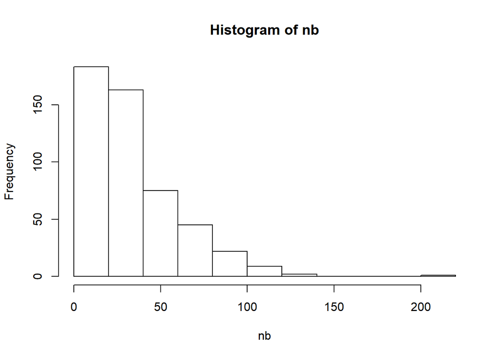

```r
hist(nb)
```

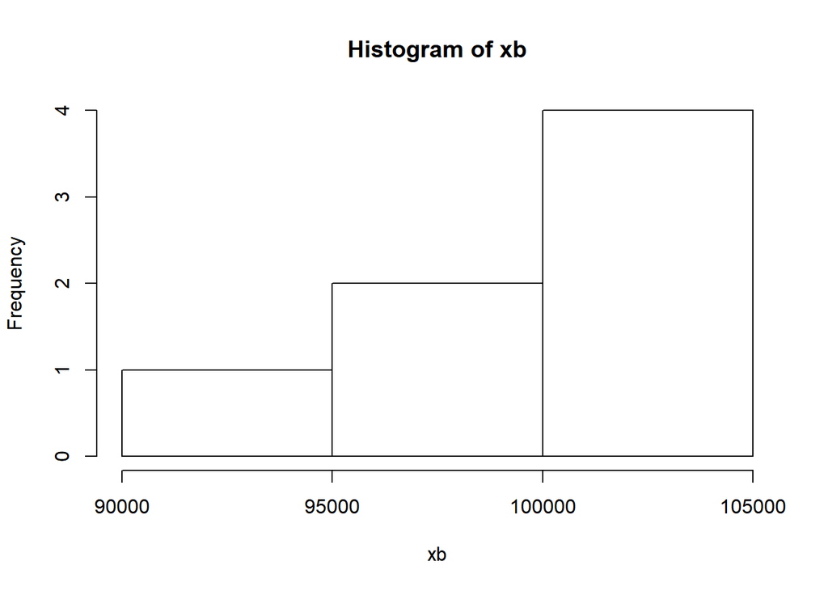

```r
hist(xb)
```

**TesteS de Aderência** O teste ks observa a máxima diferênça absoluta entre a função de distribuição teórica e a função de distribuição empírica. Sua hipótese nula é que os dados seguem uma distribuição escolhida (No nosso exemplo, Gamma ou Binomial). Já a hipótese alternativa é que os dados não seguem a distribuição escolhhida. Quanto menor for a estatística de D, mais próxima da distribuição teórica assumida, está a distrinuição empírica.

**Para a Severidade**

```r
ks.test(x, "pgamma", a, b)
```

```
##
##  One-sample Kolmogorov-Smirnov test
##
## data:  x
## D = 0.52139, p-value < 2.2e-16
## alternative hypothesis: two-sided
```

```r
ks.test(xb, "pgamma", a, b)
```

```
##
##  One-sample Kolmogorov-Smirnov test
##
## data:  xb
## D = 0.17744, p-value = 0.9529
## alternative hypothesis: two-sided
```

**Para a Frequência**

```r
ks.test(n, "rnbinom", r, p)
```

```
##
##  One-sample Kolmogorov-Smirnov test
##
## data:  n
## D = 183.26, p-value < 2.2e-16
## alternative hypothesis: two-sided
```

```r
ks.test(nb, "rnbinom", r, p)
```

```
##
##  One-sample Kolmogorov-Smirnov test
##
## data:  nb
## D = 139.66, p-value < 2.2e-16
## alternative hypothesis: two-sided
```

$$Pp= E[S]*(1+θ)$$

$$E[X]= ∑ x*p(x)$$

$$V[X]= α/(β^2)$$

$$E[X^2]=∑ (x^2)*p(x)$$

$$V[X]= E[X^2]-{E[X]^2}$$

$$Dp[X]= √(v[x])$$

$$Cv[X]= (Dp[x])/(E[x])$$

$$E[N]= (r*q)/p$$

$$V[N]= (r*q)/(p^2)$$

$$Dp(N)= √(v[N])$$

$$Cv[N]=(Dp[N])/(E[N])$$

$$E[Scol] = E[N]*E[X]$$

$$V[Scol] = V[X]*E[N] + E[X]2 *V[N]$$

$$Dp[Scol]= √(V[Scol])$$

$$Cv[Scol]=(Dp[S])/(E[S])$$

$$p = En/Vn$$

$$r = (En*p)/(1-p)$$